# All (Basic) Things Python

## Lecture Series: Day 4

# What is Python?

Python is a high-level, dynamically typed, object-oriented, interpreted programming language.

- nowadays, Python is multi-paradigm

Uses include:

- Web programming (static and dynamic)
- CGI scripting
- Scripting
- Scientific computing
- (More recently) Ariticial intelligence.

## Python is...

### good at

- Readability
- Community
- Libraries
- Scripting
- Quick Typing

### bad at

- Memory Management (non existent)
- CPU Load (Difficult)
- GIL (multiprocessing vs multithreading)

### Version

- Python 3.7 is current (USE THIS)
- Python 2.7 is what a lot of old code uses
- 3.x introduced more Pythonic and memory efficient methods

### Pip

Python package manager. If pip exists in root (`which pip`) then need root access to use! Go over Monday's Lecture for local installations. `pip`

- `search X`
- `install X`
- `uninstall X`
- `show X`

Packages I suggest:

- cython, mathplotlib, ipython, jupyter, numpy, scipy, sklearn, emcee

# Hello World

The first thing in any programming language is to write "Hello World!"

```python
message = "Hello World!"
print(message)
```

```
Hello World!
```

```python
print("Hello World!")
```

```
Hello World!
```

# Types

Python requires a working knowledge of simple data types like strings and numbers. Numbers can be broken down into two categories that are very similar in function: integers (int) and floating point numbers (float). We can use variables to store values.

Common types in base python are:

- int
- float
- str
- list
- dict
- tuple
- sets
- generators
- function
- class

```python
x = 10
print(x,type(x))
x = 10.
print(x,type(x))
```

```
10 <class 'int'>
10.0 <class 'float'>
```

```python
x = [0,1,2,3]
print(x,type(x))
x = (0,1,2,3)
print(x,type(x))
x = set([0,1,1])
print(x,type(x))
x = (lambda x: x + 1)
print(x,type(x))
print(x(10), type(x(10)))
```

```
[0, 1, 2, 3] <class 'list'>
(0, 1, 2, 3) <class 'tuple'>
{0, 1} <class 'set'>
<function <lambda> at 0x7fe2c1daf620> <class 'function'>
11 <class 'int'>
```

# Lists and Tuple

Lists are also a crucial data type. A list is a collection of objects in a particular order. Unlike other array-like data structures you might see in other languages, the items in a Python list do not have to be related and are also mutable.

Square brackets are used to indicate a list while parenthesis are used to denote tuple. Here we will create a list of strings:

```python
groceries = ['eggs',
             'milk',
             'cheese',
             'breadloaf']

groceries.append(0)

print(groceries,type(groceries))
print(groceries[0]) # indexing starts at 0
# print(groceries[5]) # raises error
```

```
['eggs', 'milk', 'cheese', 'breadloaf', 0] <class 'list'>
eggs
```

```python
# parenthesis are used to denote tuple
# much faster and more memory efficient
# immutable
money = (100,500,300,150)
print(money,type(money))
print(len(money),money[3])
# money.append(1000) # raises an error
```

```
(100, 500, 300, 150) <class 'tuple'>
4 150
```

# List Slicing

List slicing is a mechanic which allows one to access multiple elements at once.

```python
print(groceries[-1])
print(groceries[0:2])
print(groceries[0::3])
print(groceries[:])
print(groceries[::-1])
```

```
0
['eggs', 'milk']
['eggs', 'breadloaf']
['eggs', 'milk', 'cheese', 'breadloaf', 0]
[0, 'breadloaf', 'cheese', 'milk', 'eggs']
```

# Dictionary

Easy to access:

- key-value pairs.
- keys are unique
- values can be anything (even other dictionaries and objects)

Dictionaries are good for modeling objects with different types of data.

```python
alien = {'color'  :'green',
         'money'  :5,
         'clothes':['hat','shirt','alien-pants'],
         'color'  :'red',
         'job'    : ('abductor','400 schmeckles'),
         'pay'    : (lambda x: x + 400)}

print(alien.keys())
print(alien['color'])
print(alien['money'])
print(alien['clothes'])
```

```
dict_keys(['color', 'money', 'clothes', 'job', 'pay'])
red
5
['hat', 'shirt', 'alien-pants']
```

# Arithmetic

```python
print(2. * (3 + 0.14 + 0.00159265))
print(2**4)
print(2.**4)
print('Once' * 1, 'Twice' * 2, 'Thrice' * 3)
```

```
6.2831853
16
16.0
Once TwiceTwice ThriceThriceThrice
```

# Loops and Expressions

if Statements and loops are handled as they are in other languages, but the particular syntax is given below.

One thing to remember is that the expressions observed in if statements and while loops boil down to either True or False. for loops will loop through iterables (lists, tuples, numpy arrays, etc.).

```python
# if structure
x = 0
if x == 0:
    print(x)
    x = 1
elif x == 1:
    print(x)
else:
    print('not true!')

# x =1
# while structure
while x != 0:
    print('Changing x from {} to {}'.format(x,0))
    x = 0

# for loops
print(groceries)
print('Shopping List:')
for food in groceries:
    if type(food) != str:
        print('Found non string..:',food)
        break
    print('*',food)
```

```
0
Changing x from 1 to 0
['eggs', 'milk', 'cheese', 'breadloaf', 0]
Shopping List:
* eggs
* milk
* cheese
* breadloaf
Found non string..: 0
```

# try/except/else/finally

Try blocks allow temporary execution of code blocks until a break point or passing. If a break or error is thrown, the compiler moves forward to the exception blocks which handle their respective errors. Iff the try block executes without error, it passes into the else block. The finally block is always accessed

```python
def compare(a,b):
    assert a == b

# rounding error
try:
    x = 2 * 1.4 + 10.1 - 1
    y = 11.9
    compare(x,y)
except:
    print('Found Error')
else:
    print('No Errors')
finally:
    print('Finished with everything')
print(x,y)
```

```
Found Error
Finished with everything
11.899999999999999 11.9
```

# Functions

Functions are named blocks of code. Once defined, they are called to execute their task. Functions are used when a particular task needs to be performed repeatedly. Functions make code easier to write, read, test, and fix.

```python
# squares inside
a = 50
def peter(y=1,x=50):
    '''
    Multi line comments are allow more or less anywhere in python
    This function takes an argument x and returns the square
    If x not given, will return the default set of 5**2
    '''
    a = 10
    return x*x # equivalent to do x**2

# calling the function
print(peter(1j,5)) # j is complex
a = 50
print(a)
print(peter(2))
print(a) # notice prints the global a not relative
print(peter())
```

```
25
50
2500
50
2500
```

## Slightly more complex Functions

These functions not everyone uses but are extremely helpful

```python
# list comprehension
mod3 = [x for x in [1, 2, 3, 4, 5, 6, 7, 8, 9] if x % 3 == 0]
print(mod3)

# Lambda
a = (lambda x: x % 3)
print('Object:',a,' With value at 3:',a(3)) # returns modulo 3

# why use lambda? Memory efficiency trade for runtime
def transform(n):
    return lambda x: x + n
f = transform(3)
print(f(1))

# filter
mod3 = filter(lambda x: x % 3 == 0, [1, 2, 3, 4, 5, 6, 7, 8, 9])
print('Object:',mod3,' With value:',list(mod3))
print('Object:',mod3,' With value:',list(mod3))

# maps
mod3 = map(str,filter(lambda x: x % 3 == 0, [1, 2, 3, 4, 5, 6, 7, 8, 9]))
print('Object:',mod3,' With value:',list(mod3))
```

```
[3, 6, 9]
Object: <function <lambda> at 0x7fe2c1dafd90>  With value at 3: 0
4
Object: <filter object at 0x7fe2c1573400>  With value: [3, 6, 9]
Object: <filter object at 0x7fe2c1573400>  With value: []
Object: <map object at 0x7fe2c15734a8>  With value: ['3', '6', '9']
```

## Function Arguments: List

Namespace Protection

- Variables nested in functions are protected

  - ```
    def func(a):
      a = 10
      print(a)
    a = 40
    print(a,' vs ', func(a))
    ```

Pointer Passing:

- Lists that are passed to a function can change inside that function
  - even if a different variable name is used
- Similar to pointer passing in C
  - You have to make a deliberate copy to have non destructive passing

```python
def mess_with_list(a):
    a.append(0)

from copy import deepcopy
x = [10, 12, 23]
y = x
# print x
print(x)
# copy list and make change
mess_with_list(deepcopy(x))
print(x)
# don't copy and make changes to y
mess_with_list(y)
print(x)
print(y)
# dont copy and make changes to x
mess_with_list(x)
print(x)
print(y)
```

```
[10, 12, 23]
[10, 12, 23]
[10, 12, 23, 0]
[10, 12, 23, 0]
[10, 12, 23, 0, 0]
[10, 12, 23, 0, 0]
```

## Unpacking python

Functions are flexible in return types.

- You can return anything, even other functions
- Supports multi-value return
  - Separate by comma. This returns a tuple

```python
def first3():
    return 0,1,2,3,4

zero, one, two = first3()[0:3]
tup = first3()

print(zero, one, two)
print(tup)
# raises an error!
# tup[0] = 4
```

```
0 1 2
(0, 1, 2, 3, 4)
```

# External Libraries

This lecture will highlight a few packages: `numpy and matplotlib`. These packages are in many ways the canonical libraries for their respective functions.

I suggest taking a look at: ext packages: `jupyter, emcee, scipy, sklearn, and asyncio` int packages: `ipython, pickle, csv, json, math, datetime, re, os, sys, mutli(processing/threading)`

### Numpy

Speed:

- Numpy's speed comes from its vectorized operations, namely during arithmetic.
- Short of writing in C (or cython), numpys operations are as fast as python can be

First:

- `import numpy` and `a`lia`s` `np`.

Next we called NumPy's array function with a list of integers as an argument and a numpy array was returned. Note what happens when we try to change one of the elements.

```python
import numpy as np

a = np.array([0, 1, 2, 3, 4])
print(a,type(a))
a[0] = 10
print(a)
# raises an error!
# a[0] = 'fish'
```

```
[0 1 2 3 4] <class 'numpy.ndarray'>
[10  1  2  3  4]
```

### Matplotlib

Matplotlib is the standard plotting library in Python. Simple plots can be generated very quickly. There are plenty of visualization options to make publication-quality graphs. https://matplotlib.org/

I used it to create the graph in the previous lecture whose code is provided

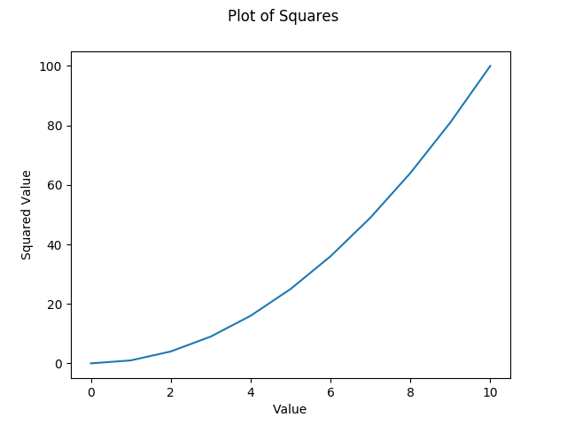

```python
%matplotlib notebook
import matplotlib.pyplot as plt
plt.xlabel("Value")
plt.ylabel("Squared Value")
plt.suptitle("Plot of Squares")
plt.plot(np.arange(11)**2)
plt.show()
```

# End of Day 4 Lecture

# Useful things

Ipython (Interactive Python Terminals) and Jupyter can be very helpful

Ipython allows for native interactions with your OS terminal (e.g. ls and cp commands work)

Jupyter provides a clean and pretty way (enhanced with Markdown) to demonstrate code and provides (IMO) the best way to demonstrate plots (you can plot in 3D and with a GUI manipulate it)